# Kapitel 7 Depression

## 7.1 Diagnoskriterier enligt ICD-10

A. Att minst två av symtomen nedstämdhet, energifattigdom och minskad aktivitet dominerat under minst de senaste två veckorna.

B. Att detta inte kan förklaras av annan kroppslig eller psykisk störning.

C. Att minst ett av följande symtom också förekommer, eller totalt minst fyra symtom från A och C:

- Förlust av självförtroende och självuppskattning
- Överdriven eller obefogad självkritik och nedvärdering av sig själv
- Återkommande tankar på död eller självmord
- All slags självskadande beteende
- Upplevd nedsättning av förmåga till tankeverksamhet och koncentration
- Vankelmod och beslutsångest
- Förändrad psykomotorisk aktivitet med minskad rörlighet eller agitation
- Sömnproblem (ökad eller försämrad sömn)
- Ökad eller minskad matlust med medföljande effekt på vikten

Vid lindrig depression är patienten i obalans men kan i allmänhet genomföra normala aktiviteter.

För att måttlig egentlig depression ska föreligga krävs kriterier för lindrig depression samt minst sex symtom från A och C. Patienten är oftast så påverkad att även vardagliga sysslor är svåra att genomföra.

För diagnosen svår egentlig depression krävs att alla tre symtomen från A och minst fem symtom från C föreligger. Patienten är funktionsnedsatt, har starka självförebråelser och självmordstankar samt ofta framträdande kroppsliga symtom bland de som redovisats under punkt C.

Depressionssjukdomen kännetecknas av Att vara episodisk. En episod är minst två veckor och vanligen 3 till 12 månader. Bara ca 10 procent varar längre än två år.

## 7.2 Medicinska differentialdiagnoser och basal utredning

Rekommenderad provtagning vid depression: Hb, LPK, SR, CRP, Na, K, Krea, S-Ca, glukos, leverstatus, TSH, fritt T4, B12, folsyra. Vid misstanke om alkoholöverkonsumtion B-PEth. Blodtryck, hjärtauskultation och neurologiskt status. CT/MRT-hjärna och EEG med ledning av anamnestiska uppgifter eller fynd i somatiskt status.

Neurologiska sjukdomar att överväga: Parkinsons sjukdom, multipel skleros, encefalit, epilepsi, hjärntumörer, cerebrovaskulära sjukdomar.

Endokrina sjukdomar att överväga: Tyreoideasjukdomar, binjuresjukdomar, diabetes mellitus typ 2, andra endokrinologiska sjukdomar

Övrigt: Anemi, b12/folsyra-brist, elektrolytrubbning (särskilt hos äldre personer), smärttillstånd, infektioner, läkemedelsbiverkningar, sömnapnésyndrom, celiaki, hypogonadism.

## 7.3 Behandling

Något om psykologisk behandling av depression. Beteendeaktivering.

[Socialstyrelsens rekommendationer 2019, inklusive kunskapsunderlag](https://www.socialstyrelsen.se/globalassets/sharepoint-dokument/artikelkatalog/nationella-riktlinjer/2021-4-7339-kunskapsunderlag.pdf).

Dessa riktlinjer är något inkonsekventa:

| Tillstånd | Åtgärd | Effekt (SMD) | Rekommendation |
| --- | --- | --- | --- |
| Depressiv episod | AD Läkemedel | 0.31 (=3p) | 3, Bör erbjudas |
| Svårbeh depr | Esketamin | 4p | 10, Undantagsfall |
| GAD | Gabapentin | 0.36 | 10, Undantagsfall |

Aripiprazol som tillägg vid TRD: “minskning av depressionssymtomen (medelvärdesskillnad, MD -3,0 till -1,8) jämfört med placebo som tillägg till antidepressiva läkemedel” kommenteras med “Resultatet tyder på en modest och tveksamt kliniskt betydelsefull effekt jämfört med placebo.” emedan identisk effektstorlek för antidepressiva kommenteras med “Sammanvägt kan antidepressiva läkemedel anses ha en kliniskt relevant effekt på depressionssyndrom”.

## 7.4 Läkemedelsbehandling

Före läkemedelsbehandling bör en noggrann klinisk bedömning göras för att undersöka samsjuklighet (tex beroendesyndrom, personlighetssyndrom, ångestsyndrom) och differentialdiagnoser (tex bipolärt syndrom, ångestsyndrom) som kan ha betydelse för behandlingsval.

Guidelines on Choice and Selection of Antidepressants for the Management of Depression [30].

Backing into the future: pharmacological approaches to the management of resistant depression [31] “For patients who have failed to respond to two antidepressant trials, augmentation with atypical anti-psychotic drugs, speciﬁcally quetiapine and aripiprazole, has the best evidence for efﬁcacy, though older treatments such as lithium and triiodothyronine still have utility.”

Comparative efficacy and acceptability of 21 antidepressant drugs for the acute treatment of adults with major depressive disorder [32] “In head-to-head studies, agomelatine, amitriptyline, escitalopram, mirtazapine, paroxetine, venlafaxine, and vortioxetine were more effective than other antidepressants”

Selective serotonin reuptake inhibitors versus placebo in patients with major depressive disorder [**Jakobsen2017?**].

Effektstorlek [Ref Cipriani, Eriksson].

### 7.4.1 Val av första behandling

Det finns flera teoretiska argument för att olika individer skulle kunna svara olika väl på antidepressiv behandling (polymorfismer i CYP-systemet, polymorfismer receptorer; skillnader i -neuroanatomi, symtom, svårighetsgrad, samsjuklighet, kön, ålder, och genes). Klinisk erfarenhet tycks också underbygga detta. Trots det har man i vetenskapliga studier ej kunnat påvisa att någon enskild faktor förutsäger respons på visst antidepressivt läkemedel.

Olika antidepressiva läkemedel har liknande effektstorlek vid behandling av depression[32]. Det finns inga faktorer som kan använads för att förutsäga vilket läkemedel som har bäst effekt i en viss patientgrupp, men följande faktorer kan beaktas för ett pragmatiskt preparatval[29]:

- Samsjuklighet med tex ångestsyndrom
- Psykotiska symtom
- Respons på- och biverkningar av tidigare antidepressiv behandling
- Potentiella interaktioner med befintlig läkemedelsbehandling
- Förväntad biverkningsprofil
  - Risk för viktuppgång
  - Initial ångeststegring och försämrad sömn av SSRI
  - Riskklassificering avseende arytmirisk (vid hög ålder, hjärt-kärlsjukdom mm) SE TdP-kapitlet
- Enkelhet (antal doser, behov av monitorering)
- Graviditetsplaner (överväg psykoterapi som ett alternativ, sertralin kan vara ett förstahandsval vid läkemedelsbehandling)

Biverkningsprofil och interaktioner med befintlig läkemedelsbehandling bör vägas in. Vid psykotiska symtom rekommenderas samtidig behandling med antipsykotiskt läkemedel. Vid sömnstörning kan mirtazapin eller agomelatin vara att föredra. Duloxetin kan ha smärtlindrande effekt. Bupropion är viktneutralt och kan vara av värde vid samtidig ADHD. Vid samsjuklighet med ångestsyndrom kan ett läkemedel som har indikation för detta med fördel användas.

#### 7.4.1.1 Samsjuklighet och subtyp av depression

**Framträdande ångest** vid en depressiv episod kan defineras som förekomst minst två av följande: Känsla av att vara spänd, rastlöshet, koncentrationssvårigheter pga oro, rädsla för att något katastrofalt skall inträffa eller känsla av att man kommer att tappa kontrollen över sig själv. I dessa fall, eller om det föreligger samsjuklighet med något ångestsyndrom rekommenderas ett antidepressivt medel som har visad effekt vid generaliserat ångestsyndrom [33]. Någon skillnad mellan grupperna SSRI, SNRI, och bupropion har inte påvisats i detta avseende [29].

**Katatoni** vid depression bör föranleda behandling med bensodiazepiner [29] och/eller ECT REF.

Med **melankoliska drag** menas enligt DSM-5 antingen anhedoni eller minskad respons på sådant som normalt är lustfyllt, tillsammans med minst tre av följande: Depression som är värre på morgonen, tidigt morgonuppvaknande (minst två timmar tidigare än vanligt), observerbar psykomotorisk hämning eller agitation, betydande viktförlust eller anorexi, överdrivna eller omotiverade skuldkänslor. Man har studerat TCA och SNRI för denna typ av depression, men det har inte framkommit någon grund för att det skulle ha betydelse för preparatval [29]. Inte heller vid **atypiska drag** har något antidepressivt medel visat sig mer effektivt [29].

Vid **depression med psykos** rekommenderas samtidig behandling med antidepressivt läkemedel och ett antipsykotiskt preparat [29]. Hur länge den antipsykotiska behandlingen bör fortgå är okänt, men en tumregel kan vara 6-12 mån [REF Maudsley]. I dessa fall bör även ECT-behandling övervägas REF.

**Depression med blandade drag** förekommer vid bipolärt syndrom med samtidig mani eller hypomani, eller vid unipolär depression när hypomaniliknande symtom föreligger samtidigt som depressionen. Tecken på detta är förhöjt stämningsläge, grandiositet, talträngdhet, rusande tankar eller ideflykt, riskfyllt beteende, och minskat sömnbehov. I dessa fall finns visst stöd för monoterapi med lurasidon eller ziprasidon.

Vid **säsongsbunden depression** har SSRI, bupropion, agomelatin, och moclobemid studerats, men några skillnader mellan antidepressiva har ej konstaterats.

Vid **depression med kognitiv dysfunktion** finns visst stöd för att antidepressiva (vortioxetin, bupropion, duloxetin, SSRI, moclobemid) ger förbättring av kognitiva funktioner. Duloxetin och vortioxetin kan möjligen vara något mer effektivt i detta avseende, men data är osäkra.

Vid **sömnstörning** kan ett medel med positiv eller neutral effekt på sömnen vara lämpligt, vilket dock bör vägas mot biverkningar (tex dagtrötthet) och behov av monitorering. Läkemedel som kan övervägas är agomelatin, mirtazapin, kvetiapin, och trazodon (ej registrerat i Sverige).

Vid **depression med somatiska symtom** är det främst samtidig förekomst av smärta som har studerats. Läkemedel som kan övervägas i dessa fall är duloxetin eller annan SNRI. Vid uttalad orkeslöshet bupropion eller SSRI. Vid låg energinivå duloxetin. Notera dock att jämförande studier saknas.

#### 7.4.1.2 Första behandling

Tabell 7.1: Förstahandsval enligt CANMAT

| label | receptor_profile | dose |
| --- | --- | --- |
| Agomelatine | MT1 and MT2 agonist and 5-HT2 antagonist | 25-50 mg |
| Bupropion | NDRI | 150-300 mg |
| Citalopram | SSRI | 20-40 mg |
| Desvenlafaxine | SNRI | 50-100 mg |
| Duloxetine | SNRI | 60 mg |
| Escitalopram | SSRI | 10-20 mg |
| Fluoxetine | SSRI | 20-60 mg |
| Fluvoxamine | SSRI | 100-300 mg |
| Mianserina | a2-Adrenergic agonist and 5-HT2 antagonist | 60-120 mg |
| Milnaciprana | SNRI | 100 mg |
| Mirtazapine | a2-Adrenergic agonist and 5-HT2 antagonist | 15-45 mg |
| Paroxetine | SSRI | 20-50 mg or 25-62.5 mg for CR version |
| Sertraline | SSRI | 50-200 mg |
| Venlafaxine | SNRI | 75-225 mg |
| Vortioxetine | SRI and 5-HT1A agonist and 5-HT1B partial agonist and 5-HT1D 5-HT3A 5-HT7 antagonist | 10-20 mg |

Tabell: Egenskaper hos några antidepressiva läkemedel

| Substans | Namn | Normaldos | Vikt | Notering |
| --- | --- | --- | --- | --- |
| Escitalopram | Cipralex | 10 | Rent ‘SSRI’ |  |
| Citalopram | Cipramil | 20 | $\uparrow$ | Escitalopram + overksam molekyl |
| Sertralin | Zoloft | 50 | $\rightarrow$ |  |
| Fluoxetin | Fontex | 20 | $\rightarrow$ |  |
| Paroxetin | Seroxat | 20 | $\uparrow$ | $\uparrow$Utsättningssymtom |
| Duloxetin | Cymbalta | 60 |  | ‘SNRI’, smärtstillande |
| Venlafaxin | Efastad | 75 | $\rightarrow$? | ‘SNRI’, $\uparrow$utsättningssymtom |
| Vortioxetin | Brintellix | 10 |  | Vid högre dos $\uparrow$illamående |
| Amitriptylin | Saroten | 125 | $\uparrow$ | Sövande, smärtstillande |
| Bupropion | Voxra | 150 | $\downarrow$ | Rökavvänjning, ADHD |
| Agomelatin | Valdoxan | 25 |  | Sövande? |
| Mirtazapin | Mirtin | 15 | $\uparrow$ | Sövande, $\downarrow$illamående |

**Sexuella biverkningar:** Mindre vanligt med läkemedlen mirtazapin, bupropion, agomelatin, och låg dos (max 10 mg) vortioxetin.

**Viktuppgång:** De flesta antidepressiva kan ge viktuppgång (0-3 kg). Det är vanligare tex vid behandling med mirtazapin, paroxetin, och amitriptylin. Sertralin och fluoxetin är mer vikneutrala och bupropion brukar ge litet viktnedgång.

**Illamående:** Mirtazapin, agomelatin och kanske bupropion kan vara att föredra.

**Sömnproblem:** Mirtazapin (ger sömn) eller agomelatin (‘sömnneutralt’) kan vara att föredra.

**Övrigt:** Mirtazapin är en antihistamin och fungerar därför mot tex pollenallergi. Bupropion kan minska ADHD-symtom. Vid behandling med agomelatin brukar man följa leverproverna första halvåret.

**Agomelatin:** Detta läkemedel har fördelen att det mer sällan ger sömnproblem och sexuella biverkningar. Ungefär 1-2 av 100 som behandlas får dock påverkade leverprover. Därför följer man leverproverna första halvåret. Allvarlig leverpåverkan är mycket sällsynt och risken minskas genom att man följer proverna på detta sätt och avslutar behandlingen om de påverkas. För extra säkerhet kan det vara bra att känna till tecken på leverpåverkan: Gulfärgad hud, mörk urin, blek/vitaktig avföring, smärta i övre högra delen av magen, och trötthet. Risken för levertransaminasstegring med agomelatin är kring 2.5% (0.5% med placebo) och det är oklart om risken skiljer sig från andra antidepressiva[34].

#### 7.4.1.3 Effektivitet

Effektiviteten av antidepressiva är omdiskuterad. Ett stort problem är publikationsbias, där negativa studier sällan publiceras. Värdering av effekt i tex metaanalyser bör därför inkludera opublicerade studier. Placeboeffekten (eller regression till medelvärdet) är dock betydande. Effektstorleken för antidepressiva är ~ 0.3 (motsvarar 2-3 poäng på MADRS eller 10% symtomreduktion jfr placebo). Lägre efficacy hos äldre, se 7.6.

Ibland hävdas att antidepressiva har större effekt vid svårare depression jämfört med lindrigare. Detta tycktes bekräftas av en metaanalys som visade att fler av de studier som visade effekt av antidepressiva inkluderade patienter med svårare depression[35,36]. En senare analys antydde att skillnaden berodde på mindre respons på placebo i dessa studier[36]. Se även diskussionsdelen i [37], där STAR-D mm diskuteras.

Dock visar en senare analys där individdata använts (detta är en bättre metod för att undersöka interaktion mellan behandling och svårighetsgrad) att det saknades en interaktion mellan svårighetsgrad och effekt av läkemedel[38] (N=10737). Det kan noteras att en liknande men mindre analys (N=718) visade en interaktion mellan svårighetsgrad och behandlingseffekt, men att döma av Figur 2 i den artikeln berodde det på ett litet antal outliers[39].

Den hittills största analysen av publicerade och opublicerade data på effekt av antidepressiva är “Selective serotonin reuptake inhibitors versus placebo in patients with major depressive disorder. A systematic review with meta-analysis and Trial Sequential Analysis” [32].

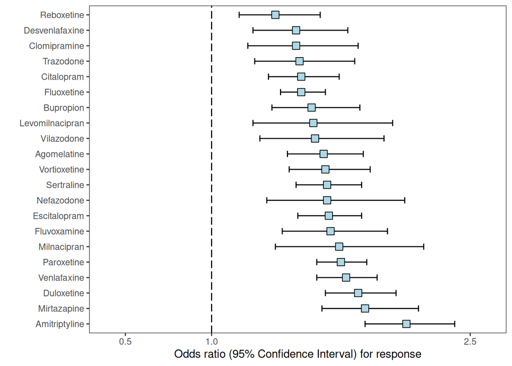

Figur 7.1: Forest plots of network meta-analysis of all trials for efficacy and acceptability

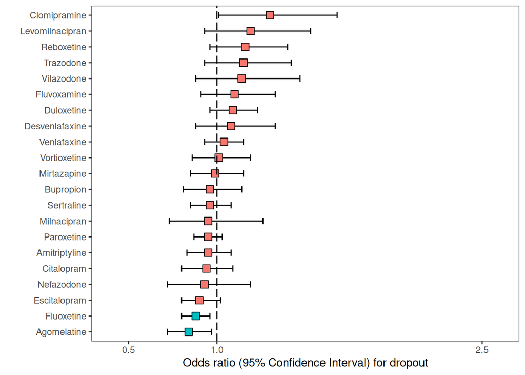

Figur 7.2: Forest plots of network meta-analysis of all trials for efficacy and acceptability

En strategi kan således vara att starta med escitalopram, venlafaxin, agomelatin (kräver monitorering av leverfunktion) eller vortioxetin (dyrt) om det inte föreligger andra faktorer som bör styra valet.

Om patienten får biverkningar eller utebliven effekt kan ett annat förstahandsval provas.

Andrahandsval enligt CANMAT visas i (**Tabell 7.2**)

Tabell 7.2: Andrahandvsal enligt CANMAT

| label | receptor_profile | dose |
| --- | --- | --- |
| Tricyclic antidepressants | various | various |
| Levomilnacipran | SNRI | 40-120 mg |
| Moclobemide | Reversible inhibitor of MAO-A | 300-600 mg |
| Quetiapine | Atypical antipsychotic | 150-300 mg |
| Selegiline transdermal | Irreversible MAO-B inhibitor | 6-12 mg |
| Trazodone | SRI and 5-HT2 antagonist | 150-300 mg |
| Vilazodone | SRI and 5-HT1A partial agonist | 20-40 mg |

Tredjehandsval enligt CANMAT visas i (**Tabell 7.3**)

Tabell 7.3: Tredjehandsval enligt CANMAT

| label | receptor_profile | dose |
| --- | --- | --- |
| Phenelzine | Irreversible MAO inhibitor | 45-90 mg |
| Tranylcypromine |  | 20-60 mg |
| Reboxetine | NRI | 8-10 mg |

#### 7.4.1.4 Effektivitet vid underhållsbehandling

Enligt metaanalys av 16 studier på underhållsbehandling[40], för de som svarar på initial behandling är risken för återfall (6-12m) 40% med placebo vs 20% med underhållsbehandling. Liknande resultat i andra metaanalyser [41] (K=31, N = 4410) och [42] (K=40, N=8890). Andra hävdar att antidepressiva **ökar** risken för återfall efter att de satts ut[43]. Ingen av dessa analyser tar i beaktande problemet med “enrichment”, vilket diskuteras utförligt i [37].

Dock finns betydande problem med studier av underhållsbehandling[37]:

- Oftast “post-marketing”, **publikationsbias?**
- Enrichment design:
  - Endast de som redan svarat på behandlingen akut tas med.
  - Detta överdiver sannolikt effekten av läkemedel vs placebo.
- De flesta återfallen i dessa studier sker inom 6 månader
  - Dvs mäter egentligen i relaps den “akuta” fasen
  - Räknar man endast på återfall efter 6 månader eller mer finns ingen skillnad mot placebo i 5 av 6 studier[37].
- Utsättningssymtom kan misstolkas som återfall[44]

STAR*D-studien motsvarar troligen bättre verkligheten. Där bibehöll hälften av de som svarat på akut behandling remission efter ett år med fortsatt läkemedelsbehandling[37].

Se även [45,46] och Läkartidningen[47] som sammanfattar “Problemet är att randomiserade utsättningsstudier inte lämpar sig för läkemedel som ger abstinenssymtom som överlappar med grundsjukdomen”.

Se även [48] om “response rate illusion”.

### 7.4.2 Uppföljning av behandlingseffekt

Uppföljning efter nyinsättning rekommenderas efter två veckor, och därefter varje två till fyra veckor [29]. Då utvärderas:

- Tolerabilitet/Biverkningar
- Säkerhet
- Effekt på depressionssymtom

För utvärdering av effekt bör skattning av depressionssymtom med tex MADRS eller MADRS-S ingå som en del av bedömningen. Därutöver kan tex funktionsnivå och motoriska symtom behöva vägas in.

Eftersom effektstorleken för antidepressiv behandling är liten (ca 2p förbättring på MADRS), sannolikt homogen mellan individer, och placeboeffekt/naturalförlopp medför större förändringar än läkemedelseffekten, innebär det en utmaning att utvärdera närvaro eller frånvaro av antidepressiv effekt hos en individ.

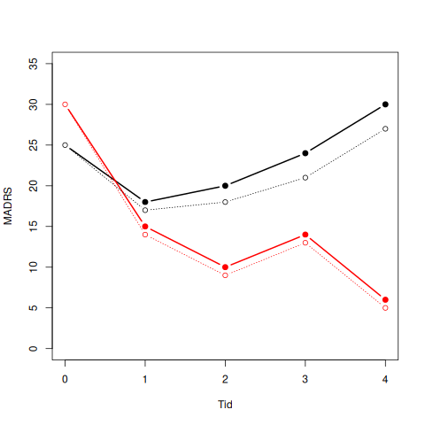

Figur 7.3: Hypotetisk illustration av behandling med placebo (heldragen linje) respektive antidepressiva (streckad linje) för två individer.

Om man förmodar att vissa patienter får en mer dramatisk positiv effekt av behandling måste man acceptera att andra patienter i samma omfattning får en försämring, för att medelvärdet skall hamna där studierna visar att det ligger. Detta illustreras nedan.

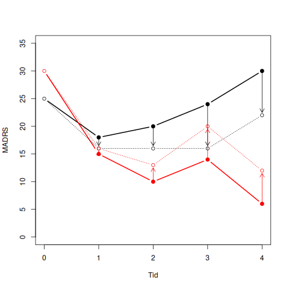

Studier som undersökt variansen i respons på läkemedel vs variansen hos placebo har funnit lika varians i båda grupperna, vilket talar för att effekten av läkemedel är ganska lika mellan individer.

### 7.4.3 Monitorering

Inför start av behandling kan blodprover och EKG vara aktuellt, beroende på vilken behandling som planeras. Agomelatin kräver monitorering av leverfunktion.

Många antidepressiva läkemedel kan förläng QTT något. Vid riskfaktorer för Torsade de Point (TdP) rekommenderas EKG före behandling och en tid efter insättning (Se avsnitt 16.16.1).

Hos äldre eller samtidig behandling med tiazid: Följ upp natrium (hyponatremirisk).

### 7.4.4 Byte av antidepressiva

Det finns ingen god vägledning huruvida byte inom eller mellan klasser skulle vara mer fördelaktigt. En strategi är därför att låta biverkningsproifilen avgöra. En metaanalys konstaterar:

> After a first SSRI, any switch within or between classes of antidepressants appears legitimate (second SSRI, novel dual-acting antidepressants, selective norepinephrine or nor-adrenergic/dopaminergic agents, or tricyclic anti-depressant or mianserin). No unequivocal evidence is available to prove an advantage of a between-class switch. [49]

Dosering vid ut- och intitrering: Se tabell på [psychiatrinet](https://wiki.psychiatrienet.nl/wiki/Main_Page).

Vid biverkningar: Byte till annan klass har inget vetenskapligt stöd men är logiskt. Byte inom SSRI-klassen kan fungera.

Icke-respons efter 2-6 veckor förutsäger senare icke-respons. Byt efter 3-4 veckor vid helt utebliven effekt [50]. Om viss förbättring sker bör utvärdering ske efter ytterligare 3-4 veckor.

Byte inom klass har visst stöd, men byte till annan klass stöds också av en del studier [50]. Byte till annat antidepressivt preparat har inte något säkert vetenskapligt stöd, möjligen undantaget byte till vortioxetin, och kombinationsbehandling eller tillägg av ett atypiskt antipsykotiskt medel har bättre stöd [50].

### 7.4.5 Svårbehandlad depression

> The criteria included failure of treatment to reduce depressive severity by at least 50%, failure to reduce absolute depressive scores below a specific cut-off point or remission threshold, and failure to produce an asymptomatic state. In the studies reviewed, the minimum number and type of failed anti-depressant trials required to assess the presence of treatment resistance differed greatly […] However, the basic definition of TRD that is emerging from the literature is an inadequate response to at least 2 antidepressant trials of adequate dose, duration, and treatment adherence [51].

Överväg [51]:

- Följsamhet till behandling
- Annan psykiatrisk samsjuklighet (ångestsyndrom, PTSD, OCD)
- Alkohol- och drogbruk
- Medicinsk samsjuklighet (tex kronisk smärta, migrän, demens, Parkinsons sjukdom, hypothyreos)
- Samtidig läkemedelsbehandling (tex opioier, kortikosteroider, kalciumkanalblockare)
- Subtyp av depression (bipolaritet, persisterande depression, atypisk depression, psykotiska symtom)

Se CANMAT [29]

### 7.4.6 Augmentationsbehandling

Se [52].

Tabell 7.4: Augmentationsbehandling vid depression

| Läkemedel | APA | BAP | CANMAT | CPGS | ICSI | NICE | MPG | RANZCP | TMAP | WFSBP |
| --- | --- | --- | --- | --- | --- | --- | --- | --- | --- | --- |
| Atypiska AP | 2:a | 1:a | 1:a | 1:a | Ja | 1:a | 1:a | 1:a | 2:a | 1:a |
| Litium | 2:a | 1:a | 2:a | 1:a | Ja | Ja | 1:a | 1:a | Ja | 1:a |
| Lamotrigin | Ja | 2:a | Nej | Nej |  | Nej | 2:a |  | Ja |  |
| Thyroideahormon | 2:a | 2:a | 2:a | Nej | Ja | Nej | 2:a | 1:a | 1:a | 2:a |
| Modafinil | Ja | Ja | 2:a |  | Ja | Nej | Ja | Nej |  |  |
| Bupropion | Ja | Ja | 2:a | Nej | Ja | Nej | 1:a | Nej | 1:a | Nej |
| Buspiron | Ja | Ja | Nej | Nej | Ja | Nej | 2:a | Nej | 1:a | Nej |
| Ketamin |  | Nej | Ja |  | Ja |  | 2:a | Nej |  | Nej |

“Ja” innebär att läkemedlet ej specificerats som 1:a eller 2:a -handsval. “Nej” innebär att det ej rekommenderas.

Atypiska antipsykotiska medel:

> AAPs were first-line equivalents in NICE, specifically aripiprazole, olanzapine, quetiapine, and risperidone, though it was not clear that this list is exhaustive. NICE concluded that the evidence for clinical efficacy was “moderate” and cautioned that dropout and side-effect reports were more likely than for antidepressant monotherapy, particularly for quetiapine [52].

Dosering: Aripiprazol 2–15 mg/d. Kvetiapin 150–300 mg/d. Risperidon 1-3mg/d. Olanzapin 2.5–10 mg/d [52]. Använd i första hand doser i lägre deen av intervallet.

CANMAT uppdatering 2024[53] rekommenderar tillägg av aripiprazol (2-10 mg) eller brexipiprazol (0.5-2 mg) i första hand; i andra hand bupropion, esketamin, ketamin, litium, olanzapin, kvetiapin, risperidon, kariprazin (1.5-3 mg), mirtazapin, modafinil, eller T3.

Litium:

> The BAP recommended lithium as a first-line augmenter but cautioned that most studies augmented TCAs and the association with side effects.

Målkonc (dalvärde) är (0.4-)0.6–0.8(-1.2) mmol/L. Fortsätt minst 2-8 veckor och fortsätt minst ett år för återfallsprevention. Monoterapi rekommenderas ej. Gradvis nedtrappning över 3 månader om behandlingen pågått > 6 månader. Om symtomen återkommer återuppta litium i underhållsdos.

Lamotrigin:

25 mg/d i 2 veckor, öka till 50 mg/d i 2 veckor, sedan 100 mg/d i 1 vecka, med maxdos 200 mg/d i frånvaro av enzyminhibitorer eller -inducerare.

> TMAP did not discuss side effects but recommended that renal function and hepatic function tests should be conducted prior to lamotrigine treatment and repeated yearly if indicated.

> BAP recommended that lamotrigine should be continued for up to 1 year after remission, with long-term treatment considered for higher risk patients.

Bupropion:

> I kombination med SSRI, 150–300 mg/d.

Buspiron:

> The MPG listed buspirone as a second-line augmenter when added to an SSRI.

Thyroideahormon:

Liotyronin 25 mkg/d, ökas till 50 mcg/d efter ~1 vecka vid otillräcklig respons.

Kontrollera TSH, T3, T4 vid start och efter 3 och 6 månader, därefter årligen. Målet är TSH i lägre normalintervallet och frånvaro av symtom på hypertyreos. Fritt T3 kan ligga i övre delen av referensintervallet. Bentäthetsmätning varje 2 år för postmenopausala kvinnor[**Touma2017?**].

Symtom på hyperthyreos: Nervositet, ångest, irritabilitet, överaktivitet, humörsvängningar, sömnsvårigheter, trötthet, värmeintolerans, muskelsvaghet, diarré, ökad miktionsfrekvens, ökad törst, klåda, minskad sexlust, palpitationer, finvågig tremor, svettning, röda handflator, lösa naglar, urticaria, håravfall, viktförlust med ökad aptit, röda eller torra ögon, illamående, feberkänsla, huvudvärk.

Se Liothyronine for Depression: A Review and Guidance for Safety Monitoring touma [**Touma2017?**]

Modafinil:

> CANMAT recommended modafinil as a second-line adjunctive agent citing a meta-analysis of 4 MDD RCTs.

FASS: Rekommenderad startdos är 200 mg dagligen. Doser upp till 400 mg i en dos eller två fördelade doser kan ges till patienter som svarar otillräckligt på den initiala 200 mg modafinildosen. Kontraindikationer är okontrollerad måttlig till svår hypertension eller hjärtarytmier.

Se nätverks-metaanalys av olika augmentationsbehandlingar[54]:

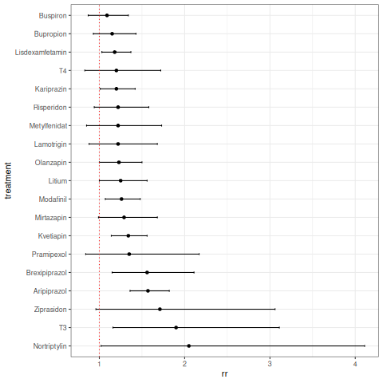

Figur 7.5: Resultat från metaanalys av respons på augmentationsbehandling[54]

### 7.4.7 Kombinationsbehandling

Studier av kombinationsbehandling med två antidepressiva vid svårbehandlad depression har visat motstridiga resultat. I metaanalyser som använder strikta inklusionskriterier blir underlaget för litet för att avgöra om kombinationsbehandling är mer effektivt än monoterapi [55,**Rocha2012?**]. I en metaanlys med bredare inklusionskriterier (n = 4511 patienter) var kombinationsbehandling bättre än monoterapi (SMD 0.29; 95% CI 0.16 to 0.42) utan att fler avslutade bahandlingen i förtid (OR 0.90; 95% CI 0.53 to 1.53). Dock var de inkluderade studierna heterogena (I2 = 63%), och det förelåg tecken till måttlig publikationsbias (fail-safe N for an effect of 0.1:44) [56]. Man fann vidare att kombinationer med monoaminåterupptagshämmare (SSRI, SNRI, och TCA) och presynaptiska a-2 blockerande antidepressiva (tex mirtazapin) möjligen var mer effektivt än andra kombinationer (SMD 0.47; 95% CI 0.24 to 0.71, jämfört med SMD 0.17; 95% CI 0.02 to 0.32, P = 0.03). CANMAT-riktlinjerna rekommenderar i första hand tillägg av ett atypiskt antipsykotiskt medel (aripiprazol, kvetiapin eller risperidon) vid svårbehandlad depression (dvs där man provat minst två antidepressiva i monoterapi), emedan tillägg av ett ytterligare antidepressivt medel rekommenderas i andra- (bupropion, mirtazapin) eller tredje hand (andra antidepressiva) [29].

### 7.4.8 Dosering av antidepressiva

Ekvivalenter som användes var (avrundat): fluoxetin 20, escitalopram 10, citalopram 20, paroxetin 20, sertralin 50, venlafaxin 75, mirtazapin 25.

Sammanfattningsvis är låga till måttliga doser av SSRI optimala, se även [59].

Maudsley Prescribing Guidelines in Psychiatry påtalar att det finns minimalt med vetenskapligt stöd för att öka dosen av ett SSRI när man tittar på totalpoängen för HDRS, men att det möjligen kan påverka symtomet nedstämt humör positivt. Visst stöd finns för att dosökning av escitalopram, venlafaxin och tricykliska kan vara fördelaktigt [50].

Startdos, maxdos, max effektiv dos, optimal dos

Tabell UpToDate: https://www.uptodate.com/contents/image?imageKey=PC%2F53818&topicKey=PSYCH%2F1725&source=see_link

max effektiv dos = där effektvinstan planar ut, optimal dos = balans mellan effekt och biverkningar

### 7.4.9 Effekt på enskilda depressionssymtom

Eriksson et al [60]

### 7.4.10 Biverkningar

De vanligaste biverkningarna av SSRI är illamående, hosta, diarré, asteni, buksmärta, nervositet, dyspepsi, tremor, och sexuella problem.

Antidessiva kan även ge tex hyperhidros (antikolinerg effekt), ökad blödningsrisk (ca 1.5x ökad risk för magblödning, 5x om samtidigt NSAID[61]), försämrad spermiekvalitet[62,63], QT-tidsförlängning, hyponatremi (1-7%, oftast övergående), förlust av benmassa och dubblerad risk för frakturer[64]. En del påverkar även kramptröskeln. Se avsnittet “Biverkningar av psykofarmaka” i kapitlet om psykofarmakologi.

[Se socialstyrelsen om risk för frakturer av SSRI](https://www.sbu.se/en/publications/responses-from-the-sbu-enquiry-service/risk-of-fractures-in-patients-treated-with-selective-serotonin-reuptake-inhibitors-ssri/)

Det finns vissa skillnader mellan olika preparat. Tex ger bupropion, mirtazapin, agomelatin, och måttlig dos vortioxetin mindre risk för sexuella biverkningar och bupropion ger mindre viktuppgång (i medeltal minskad vikt).

Nedan följer figurer som visar den relativa risken för olika biverkningar och preparat jämfört med placebo [65].

#### 7.4.10.1 Jämförelse biverkningar mellan preparat

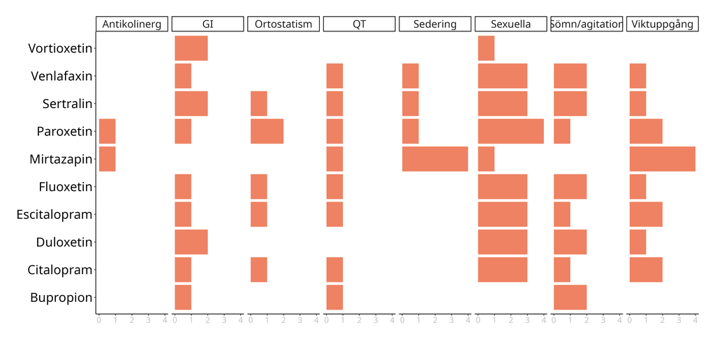

Figur 7.6: Jämförelse biverkningar.

#### 7.4.10.2 Jämförelse biverkningar mot placebo

Relativt vanliga biverkningar visas i figuren. Procentsiffran är förekomsten i placebogruppen. Fyllda cirklar innebär statistiskt signifikanta skillnader mot placebo i studien som data hämtats från[65]. Cirkelns storlek motsvarar incidensen. Risk ration på x-axeln motsvara hur många gånger ökad (eller minskad) förekomst det är i behandlingsgruppen jämfört med placebo.

Exempel: Tremor är ovanligt i placebogruppen (ca 1%) men ganska vanligt vid antidepressiv behandling (2-8%).

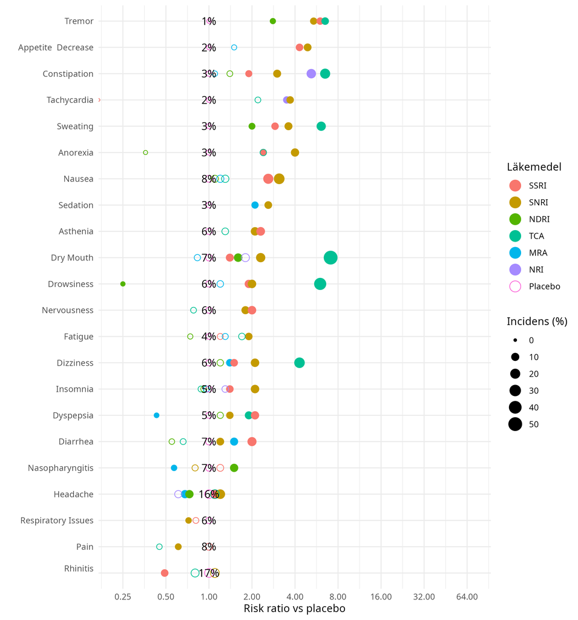

Figur 7.7: Jämförelse vanliga biverkningar mot placebo[65].

Nästa figur visar biverkningar som totalt sett (i placebo- och behandlingsgrupperna) är något ovanligare.

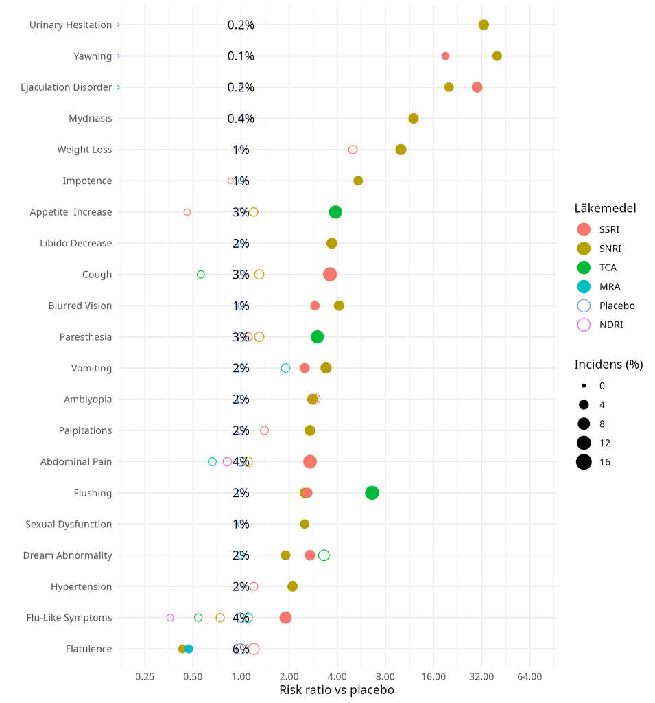

Figur 7.8: Jämförelse mindre vanliga biverkningar mot placebo[65].

#### 7.4.10.3 Biverkningar av SSRI >5% diff vs placebo

| Biverkan | Placebo (%) | SSRI (%) | Skillnad |
| --- | --- | --- | --- |
| Nausea | 8 | 21 | 13 |
| Cough | 3 | 12 | 9 |
| Diarrhea | 7 | 15 | 8 |
| Asthenia | 6 | 13 | 7 |
| Abdominal Pain | 4 | 11 | 7 |
| Nervousness | 6 | 12 | 6 |
| Dyspepsia | 5 | 11 | 6 |
| Appetite Decrease | 2 | 8 | 6 |
| Tremor | 1 | 7 | 6 |
| Ejaculation Disorder | 0 | 5 | 5 |

#### 7.4.10.4 Viktförändring av olika antidepressiva

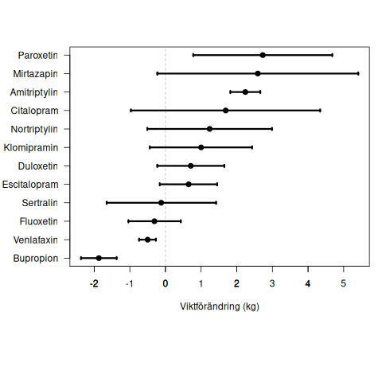

Figur 7.9: Jämförelse viktförändring[66].

OBS: Osäkra data för venlafaxin. Troligen ger det ej viktnedgång vid längre tids behandling.

Man har spekulerat huruvida viktuppgång av antidepressiva är kopplat till effekt på en viss receptor (blockering av postsynaptiska adrenerga-, kolinerga-, histaminerga-, eller serotonerga receptorer) och en del talar för att det främst är antihistaminerg aktivitet som ger viktuppgång[67].

### 7.4.11 Utsättningssymtom

Utsättningssymtom vid avslut av antidepressiva är relativt vanligt. Grovt räknat kan man säga att 10% får utsättningssymtom vid byte från placebo till placebo, dubbelt så många med escitalopram, och tre gånger så många med paroxetin eller venlafaxin.

Exempel på symtom är nervositet, ångest, sömnsvårigheter, svettningar, yrsel, irritabilitet, spändhet, illamående, och humörsvängningar. De varar oftast i 1-2 veckor (i ovanliga fall upp till ett år) och upphör snabbt vid återinsättning. Förekomsten kan troligen minskas genom gradvis uttrappning under någon eller några månader. Hyperbol nedtrappning kan övervägas.

Tala för utsättningssymtom snarare än recidiv:

- Snabb förbättring efter återinsättning
- Samtidigt uppträdande av både psykiska och fysiska (tex illamående, kräkningar, yrsel, “brain zaps”) symtom

Tabell: Incidens utsättningssymtom

| Utsatt läkemedel | DESS +4p eller mer |
| --- | --- |
| Placebo | 2-12% |
| Escitalopram | 7-27% |
| Paroxetin | 28-32% |
| Venlafaxin | 32% |

Tabellen ovan visar resultat av byte från aktiv behandling till placebo (eller från placebo till placebo)[68]. Förkortningar: DESS, Discontinuation Emergent Signs and Symptoms (DESS) checklist.

Tabell: Incidens utsättningssymtom efter olika antidepressiva

| DESSitem | Pbo | Esc5 | Esc10 | Esc20 | Par20 |
| --- | --- | --- | --- | --- | --- |
| Nervousness or anxiety | 8 | 9 | 14 | 21* | 22* |
| Trouble sleeping | 10 | 8 | 14 | 21* | 24* |
| Sweating more than usual | 4 | 7 | 13* | 13* | 21* |
| Dizziness | 7 | 10 | 12 | 27* | 40* |
| Irritability | 6 | 6 | 11 | 19* | 23* |
| Feeling tense | 7 | 9 | 10 | 18* | 19* |
| Nausea | 2 | 2 | 8 | 15* | 17* |
| Mood swings | 4 | 3 | 8 | 12* | 16* |
| Muscle tension | 4 | 3 | 8 | 12* | 16* |
| Sudden worsening of mood | 8 | 3 | 8 | 12 | 14 |
| Confusion | 4 | 4 | 8 | 10 | 17* |
| Headache | 8 | 5 | 7 | 13 | 14 |
| Bouts of crying | 2 | 3 | 6 | 13* | 11* |
| Fatigue | 11 | 6 | 6 | 11 | 17 |
| Diarrhoea | 4 | 1 | 6 | 10 | 14* |
| Increased dreaming | 5 | 6 | 5 | 16* | 19* |
| Vivid dreams | 4 | 5 | 5 | 15* | 16* |
| Muscle aches | 5 | 6 | 4 | 9 | 12 |
| Agitation | 5 | 4 | 4 | 8 | 14* |
| Shaking | 2 | 3 | 4 | 8* | 11* |
| Feeling unreal | 3 | 3 | 4 | 6 | 12* |
| Unsteady gait | 2 | 2 | 4 | 5 | 15* |
| Blurred vision | 1 | 3 | 2 | 2 | 14* |

Tabellen anger % symtom vid abrupt byte till placebo hos patienter med GAD[68]. Asterisk anger signifikant skillnad mot placebo. N ca 130 per grupp.

De flesta SSRI samt bupropion och mirtazapin har halveringstid 24-36 tim, fluoxetin 4-6 dagar. Venlafaxin 5 tim, duloxetin 12 tim.

> Case series clinical reports indicate that an abrupt cessation of ADM beyond the first month of treatment leads to relatively minor somatic withdrawal symptoms (e.g., dizziness) for about 25% of adults following treatment with ADM, and that these symptoms generally last 3–10 days. About 15% of responders upon stopping ADM medication experience longer lasting and more intense somatic and anxiety symptoms lasting at least 2–4 weeks, and approximately 7%–10% of responders experience symptoms that measurably impair health and social- emotional function lasting (without rescue ADM treatment) weeks to a few months[69]

#### 7.4.11.1 Hyperbol nedtrappning för att undvika utsättningssymtom

Det finns goda argument för att kort nedtrappningsperiod ger större risk för utsättningsesvär än en längre sådan[70]. Hyperbol nedtrappning kan vara att föredra på teoretisk grund och det kan medföra en kortare nedtrappningsperiod än linjär nedtrappning, eftersom dosen reduceras procentuellt sett mer i början[70]. Dock bör noteras att en redan en halvering av behandlingsdosen kan leda till utsättningssymtom som i sin tur kan öka risken för återfall[69].

Den teoretiska grunden för hyperbol nedtrappning baseras på att läkemedlets “occupancy” av receptorn uppvisar en hyperbol effekt, dvs att dosökning i det lägre intervallet små doser har en relativt högre effekt på bindingsgrad än dosökningar vid högre dosintervall. För att uppnå en linjär farmakologisk effekt kan därför hyperbol nedtrappning användas. Eftersom antidepressiva leder till uppreglering av postsynaptiska receptorer är det också rimligt att det tar viss tid innan dessa nedregleras. Steady-state efter en dosreduktion uppnås för de flesta antidepressiva efter ungefär 1-2 veckor, så detta kan betraktas som ett minimum för varje steg med dosreduktion. Eftersom utsättningssymtom kan kvarstå i flera veckor kan tex 4 veckor för varje nedtrappningssteg vara en strategi om varje dossteg skall utvärderas.

Nedtrappning under exempelvis en månad är troligen för snabbt för att påtagligt minska utsättningsbesvär och en lämpligare målsättning kan vara tex fyra månader[70]. Rent praktiskt kan ett förfarande vara att reducera med tex en (fyra?) veckas intervall och att backa i dos och glesa ut nedtrappningen om besvärliga utsättningssymtom inträffar. Exempel på nedtrappning[71].

Ett praktiskt problem är begränsad delbarhet av tabletter. En strategi kan vara att byta till fluoxetin som har längre halveringstid, samt finns tillgängligt som oral lösning för att uppnå de lägsta doseringarna. Eftersom fluoxetin tar längre tid att uppnå steady-state kan man teoretiskt motivera större steg vid varje nedtrappning. Dock interagera fluoxetin med en del andra läkemedel. Även escitalopram finns som oral lösning (20 mg/ml, 1 droppe = 1 mg). För läkemedel i kapslar kan ett (omständigt) alternativ vara att öppna kapseln och räkna korn (då kan dosen behöva delas upp på två tillfällen för att undvika svängningar i läkemedelskoncentration under dagen).

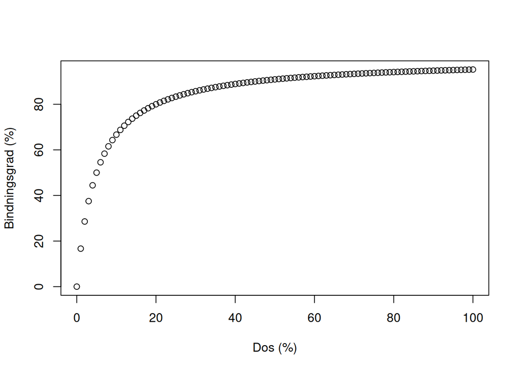

Figur 7.10: Illustration av förhållandet mellan dos och bindingsgrad

Tabell: Exempel på hyperbol nedtrappning med fluoxetin oral lösning (4 mg/ml) eller escitalopram oral lösning (20 mg/ml).

| Steg | Dos, mg | Fluoxetin, ml | Escitalopram, droppar |
| --- | --- | --- | --- |
| 1 | 40 | 10 | - |
| 2 | 20 | 5 | 20 |
| 3 | 12 | 3 | 12 |
| 4 | 8 | 2 | 8 |
| 5 | 4 | 1 | 4 |
| 6 | 2 | 1/2 | 2 |
| 7 | 1 | 1/4 | 1 |
| 8 | 0.5 | 1/8 | 0.5 |
| 9 | 0 | 0 | 0 |

? Dispergerbar tablett (20 mg) 1 => 1/2 => 1/4

Tabell: Exempel på hyperbol nedtrappning med escitalopram tablett 5 mg.

| Steg | Dos, mg | Escitalopram 5 mg, antal tabl |
| --- | --- | --- |
| 1 | 20 | 4 |
| 2 | 10 | 2 |
| 3 | 5 | 1 |
| 4 | 2.5 | 1/2 |
| 5 | 1.25 | 1/4 |
| 6 | 0 | 0 |

Fler steg med mindre doser skulle vara önskvärt, men svårt att göra praktiskt pga delning av tabletten.

### 7.4.12 Behandlingslängd och recidivprofylax

Till fullständig remission och därefter 6-12 månader. Trappa sedan ut långsamt för att undvika utsättningssymtom.

Två eller flera depressioner under en femårsperiod medför indikation för långtidsprofylax. Vid fortsatt behandling under 1-3 år halveras återfallsrisken. Återfallspreventiv psykoterapeutisk behandling bör övervägas.

Ett observandum är att i studerna på återfallsprofylax kan en del av effekten (eller hela) bero på utsättningssymtom[37,44].

För diskussion om metodfrågor och sammanfattning av relapse prevention trials, se [72]. Safer 2017[69] ger en nykter beskrivning av problemen. Se Table 2 Antidepressant and placebo responder extension studies: relapse rates, 16–52 weeks.

> […] longer initial treatment was associated significantly with a larger drug-placebo contrast (greater effect size, whether based on placebo/drug RR or the difference in relapse rates between placebo and antidepressant, RD) during continuation treatment[…] In addition, with linear regression modeling, recurrence rates with both drug and placebo increased with longer exposure time, as expected, although recurrence risk with placebo grew much more than with drug (r = +0.57 vs. +0.30, respectively)[73]

> Although entry and stabilization criteria have varied across studies, traditional relapse-prevention study designs have all included an open-label active treatment period during which patients are stabilized and achieve remission, followed by randomization to 1 of 2 arms, active or placebo[…] stabilization periods have often been <16 weeks, which may not be sufficient time to establish a sustained response[72]

> studies of antidepressant maintenance therapy have indicated that transitioning to placebo or reducing the maintenance dose by half increases the risk of relapse compared with maintaining an effective dose[69,72]

> There is an overwhelming acceptance by experts in psychiatry that antidepressant medication (ADM) is useful for the maintenance treat- ment of adults with major depressive disorder (MDD). The primary basis for this is the many (> 70) industry sponsored, placebo sub- stitution (randomized withdrawal) trials which follow a set protocol. First, restrictively (enriched) screened samples of adults diagnosed with MDD are entered into an open ADM efficacy trial. Then the responders are urged to enter into a randomized, double-blind, placebo-controlled (RDBPC) maintenance trial. At the beginning of this trial, known as a placebo substitution trial, about a third of the ADM responders are abruptly switched to placebo, whereas the other responders continue on the ADM that benefited them. The consistent result of these main- tenance trials is that those switched to placebo experience a relapse rate two or more times the rate of responders who were maintained on their antidepressant medication[69].

> However, there are other ADM randomized, controlled maintenance methodologies that present different MDD relapse outcomes. A total of five (including placebo substitution) published maintenance meth- odologies will be presented and relapse rates from their treatment trials will be detailed and compared. The totality of maintenance findings raise doubt about the value of placebo substitution trials to provide the primary rationale for antidepressant long term treatment, and ad- ditionally reveal that the issues encompassing ADM maintenance for adults diagnosed with MDD are very complex[69].

> drugs with a shorter half- life lead more rapidly to relapse[69].

> virtually all other ADM maintenance research reports document that the majority of relapses occurring after a drug discontinuation or a switch to placebo occurred during the following one to three months[69].

Fördelningen av återfall vid byte till placebo är vänsterförskjuten:

> Time to recurrence was significantly longer for escitalopram-treated patients, mean ± SD of 252 ± 134 days and median of 357 days, compared with those patients receiving placebo treatment, mean ± SD of 130 ± 135 days and median of 58 days[74] [Not: Kaplan-Meier kurvan indikerar att escitalopram och pbo divergerar främst under de första 60 dagarna]

### 7.4.13 Naturalförlopp, återfallsrisk, avslut

En studie som illustrerar återfallsrisken och problemet med utsättningssymtom visas i tabellen och figuren nedan[75]. Inklusionskriterier var minst 2 tidigare epidoser och Minst AD >9 mån, eller AD i >2å samt i remission (recovery).

Tabell: Studie av avslut av antidepressiva i primärvård[75]

| Item | Maintainance | Discontinued | Test |
| --- | --- | --- | --- |
| Randomized | 238 | 240 |  |
| Adherence | 70% | 52% |  |
| Relapse by v 52 | 92 (39%) | 135 (56%) | HR 1.56 to 2.7 |

Discontinuation var över 2 månader. Trots gradvis uttrappning identifierade 70% v patienterna att de bytt till placebo och DESS var högre fram till vecka 39.

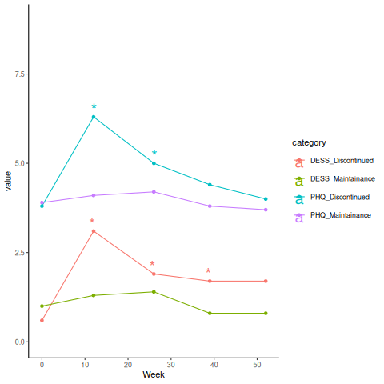

Figur 7.11: Antidepressant discontinuation PHQ and DESS

### 7.4.14 Antidepressivas effektivitet

Effekten av SSRI och andra antidepressiva är välstuderad i kliniska prövningar och metaanalyser ger stöd för att de har en viss effekt mot pågående depression[32]. Dock föreligger en publikationsbias som gjort att effektstorleken kan vara överdriven i publicerade studier[76].

I en studie av Turner et al [76] sammanställdes data från publicerade och opublicerade studier av tolv olika antidepressiva vilka innefattade ca 12000 patienter. Opublicerade resultat erhölls via det register som Food and Drug Administration håller över kliniska prövningar. Slående var att negativa eller tveksamma resultat i stor utsträckning ej publicerades.

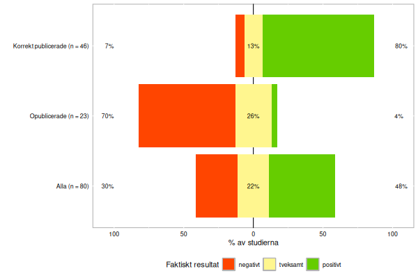

Figur 7.12: Publikationsbias för antidepressiva. Från[76]. Elva med negativt eller tveksamt resultat framställdes som positiva. Totalt N = 12564 pers..

Analysen uppdaterades 2022 och man fann en något ökad publicering av negativa resultat[77].

| Resultat | Genomförda | Publicerade | Publikation motsvarar ej resultat | N |
| --- | --- | --- | --- | --- |
| Positivt | 38 | 37 | 0 | 7155 |
| Tveksamt | 12 | 6 | 6 | 2309 |
| Negativt | 24 | 8 | 5 | 3100 |
| ———- | ———— | ————- | ———————————– | —— |

Tabell: Antal genomförda och publicerade studier klassificerade efter FDAs värdeirng av positivt/negativt/tveksamt resultat.

Effektstorleken var 0.37 (CI 0.33 till 0.41) för publicerade studier och 0.15 (CI 0.08 till 0.22) för opublicerade. Den sammanlagda effektstorleken för publicerade och opublicerade studier var 0.31. En effektstorlek på 0.2 kan betraktas som liten och 0.5 som medel (motsvarar 3 p förbättring på HAM-D och anges ibland som gränsen för “kliniskt signifikant”).

Det bör även noteras att placeboeffekten är framträdande vid behandling av depression (sannolikt även regression mot medelvärdet). Den ökar med antalet uppföljningsbesök i en studie och är kanske mindre framträdande vid svårare depression[78].

Figuren nedan visar det kumulativa resultatet av publication bias, selektivt rapporterande av utfall, spin etc.

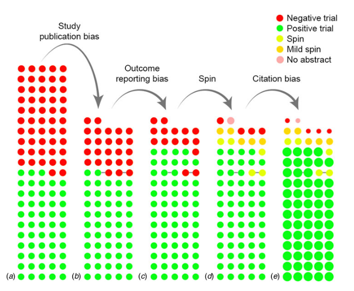

Figur 7.13: The cumulative impact of reporting and citation biases on the evidence base for antidepressants. (a) displays the initial, complete cohort of trials, while (b) through (e) show the cumulative effect of biases. Each circle indicates a trial, while the color indicates the results or the presence of spin. Circles connected by a grey line indicate trials that were published together in a pooled publication. In (e), the size of the circle indicates the (relative) number of citations received by that category of studies[79].

**Selektivt rapporterande:** By omitting unfavorable outcomes or switching the status of the primary and secondary outcomes. Without access to the FDA reviews, it would not have been possible to conclude that these trials, when analyzed according to protocol, were not positive. **Spin:** Tex spin in the abstract (i.e. concluding that the treatment was effective when it was not, or suggesting the treatment is at least numerically better than placebo). **Citation bias:** Positive trials were cited three times as frequently as negative trial

Frågor kring antidepressivas effektivitet vid akut respektive underhållsbehandling, problemen med publikationbias och studiedesign, samt betydelsen av utsättningssymtom som ett metodologiskt problem i underhållsstudier, mm, har diskuterats. Debatten är något polariserad, med olika grupperingar “för” och “emot” antidepressiva, se tex [80].

| Påstående | För | Emot | Syntes |
| --- | --- | --- | --- |
| Stor publikationsbias | [76,77] | - | Ja |
| Liten effektstorlek i studier | [32,76] | - | Ja |
| Effektstorleken ej kliniskt signifikant | [81] | [82] | Nja |
| Respons och remission problematiska mått | [48] | ? | Ja |
| Subgrupper svarar bättre | (*) | [83,84] | Nej |
| HAMD17 överskattar antidepressiv effekt | [85] | [82,85] | Nej |
| HAMD17 underskattar antidepressiv effekt | [85] |  | Litet |
| Antidepressiva är effektiva recidivprofylax | [40–42] | [37,44] | Nja |
| Effekten som recidivprofyax förklaras av utsättningsbesvär | [37,44] |  | Delvis |
| Antidepressiva har mer effekt vid svårare depression | [35,36] | [38] | Nej |
| Antidepressiva uppvisar dos-respons | [58] |  | Liten effekt |

[38]

(*)En studie som visade att variabliteten i respons på läkemedel var störree än den för placebo (ett stöd för att subgrupper av patienter svarar bättre)[86] drogs tillbaks pga felaktig analys[87].

Att det föreligger betydande publikationsbias, dvs att negativa studier ej publiceras eller att deras resultat förvanskas, tycks det råda samstämmighet om. Detta är ett stort problem när vetenskapen skall värderas. Slutsats: Värdering av antidepressivas effekt (i tex metaanalyser) måste inkludera opublicerade studier för att vara meningsfull.

Att den beräknade effektstorleken vid akut behandling är liten (SMD ca 0.3, motsvarande 2-3 poäng på HAMD17) tycks det också råda samsyn om. Effektstorleken kan vara större om endast kärnsymtom vid depression används[85], men den blir ändå liten. Huruvida detta är en kliniskt relevant effekt är omdiskuterat, men man kan svårligen kalla det för en stor effekt. En relaterad fråga är om det finns subgrupper med patienter som har en tydlig effekt, men de analyser som gjorts ger inget stöd för detta. Det kan noteras att pga stor variablitet i placeboeffekt, stor andel drop-outs, samt att depressionsskattning hos friska ej är 0, kan det vara orealistiskt att förvänta sig hög effektstorlek i randomiserade kontrollerade prövningar av antidepressiva[88].

Att antidepressiva har större effekt (eller att placeboeffekten är mindre) vid svårare depression tycks inte stämma, utan vara en artefakt av metoden som använts för att beräkna detta (metaanalys snarare än individdata)[38].

Att siffror för respons och remission är missledande tycks uppenbart med tanke på den betydande placeboeffekten. En liten effekt av antidepressiva kan därför ge skillnader i respons/remission.

Att utsättningssymtom är vanligt tycks väl belagt[68], likaså att de kan kvarstå i upp till ett år[75]. Allvarlighetsgraden av dessa är oklar, men att de kan misstolkas som återfall i depression verkar sannolikt[37,44]. Det är ett observandum att återfall i depression eftar avslut av antidepressiva i huvudsak sker tidigt efter avslut av behandlingen och överensstämmer tidsmässigt med den period då utsättningssymtom är vanligast. Med tanke på depressionens episodiska naturalförlopp skulle man snarare vänta sig en jämn spridning av återfall under observationstiden. Likaså är det förvånande att antidepressiva skulle ha en mycket större profylaktisk effekt än akut effekt.

Sammantaget verkar det sannolikt att:

1. Antidepressiva har en betydande placeboeffekt och förloppet varierar mycket mellan individer.
2. Antidepressiva ger i medeltal en liten effekt utöver placebo och den extra effekten av läkemedlet är ungefär lika för alla som behandlas.
3. Antidepressiva skyddar mot återfall, men en del av den effekten förklaras av utsättningssymtom.

En liten effekt på en skattningsskala kan ha ett värde. Dessutom kan det finnas effekt på symtom som inte fångas av skalan. Den lilla effekten jämfört med placebo gör det mycket svårt att utvärdera effekten av antidepressiv behandling hos en enskild individ. Både de som försämras och de som förbättras kan ha effekt av behandlingen eller inte. Det går inte att veta hur deras depression skulle ha utvecklats utan behandling. Detta gör det också svårt att rekommendera byte av antidepressiva eller kombinationbehandling (för båda strategierna är det vetenskapliga stödet minimalt).

Den lilla effekten jämfört med placebo gör att biverkningar bör vägas in vid beslut om fortsatt behandling.

Med tanke på att medeleffekten är liten och att dosökning över minsta effektiva dos endast ger en mycket liten ytterligare effekt, bör eventuella dosökningar och deras biverkningar utvärderas noggrannt. Om biverkningarna ökar och den eventuella positiva effekten som patienten upplever inte håller i sig, bör man överväga att återgå till lägre dos.

## 7.5 Depression i anslutning till förlossning

Ungefär 5% av mödrar drabbas av depression under graviditet eller tiden efter förlossning [Ref DSM5]. Enligt en stor finsk studie är dock incidensen av “Major depression” 0.8% under graviditet [89]. Den dominerande riskfaktorn är tidigare depression, vilket ungefär hälften av de mödrar som drabbas har haft [89]. Ofta föreligger även svår ångest och panikattacker. Psykotiska drag ses hos ungefär en på 1000 förlossningar. I DSM-5 kan depressionsdiagnosen anges som “with peripartum onset” om depressionen startat under graviditeten eller inom fyra veckor efter förlossning. Risken för återfall vid nästa graviditet är ungefär 40% [Ref: DSM5]. Mödrar som drabbas av depression bör utvärderas avseende bipolär sjukdom, postpartum-psykos och suicidrisk [90].

Barn vars mammor har depression kring förlossningen löper ökad risk för “failure to thrive”, “attachement disorder” och försenad utveckling vid ett års ålder. Dessa besvär kan förebyggas genom att mammans besvär behandlas. Depresionen medför även risker för mamman, såsom minskad energi, sömnstörningar och försämrad anknytning till barnet, liksom ökad risk för självmord [90].

Depression i anslutning till förlossning bör skiljas från “baby blues”, som är kortvarig, har milda symptom och påverkar fungerandet minimalt [90].

Mild eller måttlig depression kan behandlas med psykoterapi eller antidepressiva läkemedel emedan måttlig till svår depression bör behandlas med båda (?). rTMS och ECT bör övervägas som alternativ. Läkemedelsbehandling: Se avsnittet om SSRI vid graviditet och amning, 16.4. Se antidepressants-pregnancy.csv

Risk factors for and perinatal outcomes of major depression during pregnancy [89]

## 7.6 Depression hos äldre

Effekten av antidepressiva läkemedel är lägre i högre åldrar[91]. **Figur 7.14** visar effekten av antidepressiv läkemedelsbehandling i olika åldersgrupper [92]. Andelen som uppnår respons minskar med stigande ålder. Skillnaden mellan antidepressiv behandling och placebo minskar också i de högre åldersgrupperna. Respons definierades här som 50% eller större reduktion av depressiva symtom enligt skattingsskalorna MADRS eller HDRS.

Argument finns för att SSRI-behandling av äldre med depression saknar evidens [Läkartidningen](https://lakartidningen.se/opinion/debatt/2019/12/ssri-behandling-av-aldre-med-depression-saknar-evidens/).

Någon skillnad i behandlingseffekt mellan olika grupper av antidepressiva (TCA, SSRI, och nyare ickeselektiva serotninåterupptagshämmare) har inte kunnat påvisas [93] .

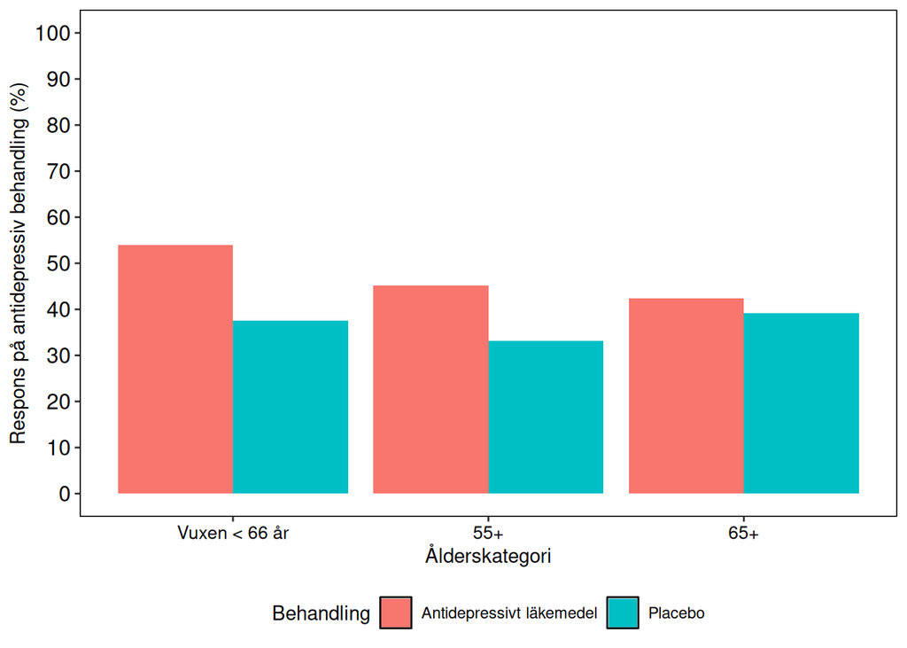

Figur 7.14: Effekt av antidepressiva läkemedel i olika åldersgrupper

| treatment | age_category | response_rate | p_vs_adult | note | Behandling |
| --- | --- | --- | --- | --- | --- |
| antidepressant | Vuxen < 66 år | 53.9 |  | Tedeschini2011 | Antidepressivt läkemedel |
| antidepressant | 55+ | 45.2 | 0.008 | Adult is <65y, late-life is >=55, older is >=65 | Antidepressivt läkemedel |
| antidepressant | 65+ | 42.4 | 0.004 | Figure Comparison (using analysis of variance) of Antidepressant and Placebo Response Rates in Younger Adult and Older Adult Patients | Antidepressivt läkemedel |
| placebo | Vuxen < 66 år | 37.6 |  |  | Placebo |
| placebo | 55+ | 33.1 | 0.320 |  | Placebo |
| placebo | 65+ | 39.2 | 0.968 |  | Placebo |

Tillägg av aripiprazol eller bupropion vid svårbehandlad depression hos äldre har studerats i en stor studie [94]. Den visade att tillägg av aripiprazol gav förbättrat välmående men ej högre andel remission än byte till- eller tillägg av bupropion.

## 7.7 Indikationer

Vid olika tillstånd.

Se notes/antidepressants-indications.csv

Se European medical agency?

### 7.7.1 Resurser

Bartels 2003 Evidence-based practices in geriatric mental health care: an overview of systematic reviews and meta-analyses [93]

FDA Prescription Drug Labeling Resources Link (https://www.fda.gov/drugs/laws-acts-and-rules/prescription-drug-labeling-resources)

FDA https://www.accessdata.fda.gov/scripts/cder/daf/index.cfm